# Project 2

# Load Packages

```r
library(tidyverse)
library(tidymodels)
library(janitor)
library(skimr)
library(vip)
library(parallel)
library(doParallel)
library(xgboost)
```

# Load Initial Data

```r
raw_data <- read_csv("../Project 2/boston_train.csv") %>%
  clean_names()

head(raw_data)
```

| pid | zipcode | own_occ | av_total | land_sf | yr_built | yr_remod | living_area | num_floors | structure_class | r_bldg_styl | r_roof_typ | r_ext_fin | r_total_rms | r_bdrms | r_full_bth | r_half_bth | r_bth_style | r_kitch | r_kitch_style | r_heat_typ | r_ac | r_fplace | r_ext_cnd | r_ovrall_cnd | r_int_cnd | r_int_fin | r_view | zip | population | … |
| --- | --- | --- | --- | --- | --- | --- | --- | --- | --- | --- | --- | --- | --- | --- | --- | --- | --- | --- | --- | --- | --- | --- | --- | --- | --- | --- | --- | --- | --- | --- |
| 10 | 2136 | Y | 321200 | 10288 | 1992 | 0 | 1681 | 1.0 | R | RR | G | M | 6 | 3 | 2 | 0 | S | 1 | S | W | N | 0 | A | A | A | N | A | 02136 | 28488 | … |
| 40 | 2124 | Y | 450500 | 3187 | 1900 | 2001 | 1868 | 2.0 | R | CL | M | W | 7 | 4 | 1 | 1 | M | 1 | M | W | N | 0 | G | G | A | N | F | 02124 | 47783 | … |
| 70 | 2130 | Y | 794300 | 6007 | 1962 | 2001 | 2146 | 2.0 | R | CL | G | M | 8 | 3 | 2 | 1 | S | 1 | S | W | N | 2 | G | G | G | N | A | 02130 | 35401 | … |
| 80 | 2136 | Y | 342100 | 5500 | 1949 | 2002 | 1357 | 1.5 | R | CP | G | M | 6 | 3 | 1 | 1 | S | 1 | S | F | N | 1 | G | A | A | N | A | 02136 | 28488 | … |
| 90 | 2124 | Y | 444700 | 3026 | 1900 | 0 | 2346 | 2.5 | R | CL | L | M | 10 | 6 | 1 | 1 | M | 1 | M | F | N | 0 | A | A | A | N | A | 02124 | 47783 | … |
| 100 | 2131 | Y | 518500 | 4950 | 1900 | 2012 | 2032 | 2.0 | R | CL | G | A | 8 | 4 | 2 | 1 | M | 1 | M | W | N | 0 | A | A | A | N | A | 02131 | 29826 | … |

```r
zip_code <- read_csv("../Project 2/zips.csv")

head(zip_code)
```

| ZIP | Population | Pop_Density | Median_Income | City_State |
| --- | --- | --- | --- | --- |
| 02132 | 36314 | 13251 | 75446 | Cambridge, MA |
| 02124 | 47783 | 15913 | 48841 | Dorchester Center, MA |
| 02131 | 29826 | 11505 | 66735 | Roslindale, MA |
| 02136 | 28488 | 6207 | 58890 | Hyde Park, MA |
| 02130 | 35401 | 10618 | 75730 | Jamaica Plain, MA |
| 02138 | 36314 | 13251 | 75446 | Cambridge, MA |

```r
holdout <- read_csv("../Project 2/boston_holdout.csv") %>%
  clean_names()
```

# First Skim

```r
raw_data %>%
  skim_without_charts()
```

```
-- Data Summary ------------------------
                           Values
Name                       Piped data
Number of rows             9959
Number of columns          33
_______________________
Column type frequency:
  character                16
  numeric                  17
________________________
Group variables            None

-- Variable type: character ------------------------------------------------------------------------
# A tibble: 16 x 8
   skim_variable   n_missing complete_rate   min   max empty n_unique whitespace
 * <chr>               <int>         <dbl> <int> <int> <int>    <int>      <int>
 1 own_occ                 0             1     1     1     0        2          0
 2 structure_class         0             1     1     1     0        1          0
 3 r_bldg_styl             0             1     2     2     0       16          0
 4 r_roof_typ              0             1     1     1     0        7          0
 5 r_ext_fin               0             1     1     1     0       10          0
 6 r_bth_style             0             1     1     1     0        4          0
 7 r_kitch_style           0             1     1     1     0        4          0
 8 r_heat_typ              0             1     1     1     0        7          0
 9 r_ac                    0             1     1     1     0        3          0
10 r_ext_cnd               0             1     1     1     0        5          0
11 r_ovrall_cnd            0             1     1     1     0        5          0
12 r_int_cnd               0             1     1     1     0        5          0
13 r_int_fin               0             1     1     1     0        2          0
14 r_view                  0             1     1     1     0        5          0
15 zip                     0             1     5     5     0        5          0
16 city_state              0             1    13    21     0        5          0

-- Variable type: numeric --------------------------------------------------------------------------
# A tibble: 17 x 10
   skim_variable n_missing complete_rate       mean         sd     p0      p25    p50    p75    p100
 * <chr>             <int>         <dbl>      <dbl>      <dbl>  <dbl>    <dbl>  <dbl>  <dbl>   <dbl>
 1 pid                   0         1      71094.     41012.        10  35780    71180 106575  142240
 2 zipcode               0         1       2131.         3.69    2124   2131     2132   2132    2136
 3 av_total              0         1     448564.    147761.    134800 347100   418700 510150 1097100
 4 land_sf               0         1       5936.      2954.       920   4319     5320   6756  107158
 5 yr_built              0         1       1933.        35.3        0   1910     1931   1955    2016
 6 yr_remod            347         0.965    676.       947.         0      0        0   1997    2016
 7 living_area           0         1       1659.       546.       332   1300     1554   1914    8623
 8 num_floors            0         1          1.73       0.448      1      1.5      2      2       3
 9 r_total_rms           0         1          7.11       1.55       3      6        7      8      17
10 r_bdrms               0         1          3.34       0.924      0      3        3      4       9
11 r_full_bth            0         1          1.35       0.557      1      1        1      2       6
12 r_half_bth            0         1          0.564      0.547      0      0        1      1      10
13 r_kitch               0         1          1.02       0.137      1      1        1      1       3
14 r_fplace              0         1          0.596      0.622      0      0        1      1       5
15 population            0         1      34872.      6299.     28488  29826    35401  36314   47783
16 pop_density           0         1      11369.      3294.      6207  10618    11505  13251   15913
17 median_income         0         1      65984.      9750.     48841  58890    66735  75446   75730
```

after skimming, PID, ZIPCODE should be transformed into categorical

zip - already there we can just remove PID, ZIPCODE

train - 33 variables holdout - 32 variables

# Transformation and Merge

```r
raw_data$yr_built <- as.character(raw_data$yr_built)
raw_data$yr_remod <- as.character(raw_data$yr_remod)

holdout$yr_built <- as.character(holdout$yr_built)
holdout$yr_remod <- as.character(holdout$yr_remod)

raw_data %>%
  select(-pid, -zipcode) %>%
  mutate_if(is.character, factor) %>%
  clean_names() -> raw_data

raw_data %>%
  skim_without_charts()
```

```
-- Data Summary ------------------------
                           Values
Name                       Piped data
Number of rows             9959
Number of columns          31
_______________________
Column type frequency:
  factor                   18
  numeric                  13
________________________
Group variables            None

-- Variable type: factor ---------------------------------------------------------------------------
# A tibble: 18 x 6
   skim_variable   n_missing complete_rate ordered n_unique
 * <chr>               <int>         <dbl> <lgl>      <int>
 1 own_occ                 0         1     FALSE          2
 2 yr_built                0         1     FALSE        170
 3 yr_remod              347         0.965 FALSE         77
 4 structure_class         0         1     FALSE          1
 5 r_bldg_styl             0         1     FALSE         16
 6 r_roof_typ              0         1     FALSE          7
 7 r_ext_fin               0         1     FALSE         10
 8 r_bth_style             0         1     FALSE          4
 9 r_kitch_style           0         1     FALSE          4
10 r_heat_typ              0         1     FALSE          7
11 r_ac                    0         1     FALSE          3
12 r_ext_cnd               0         1     FALSE          5
13 r_ovrall_cnd            0         1     FALSE          5
14 r_int_cnd               0         1     FALSE          5
15 r_int_fin               0         1     FALSE          2
16 r_view                  0         1     FALSE          5
17 zip                     0         1     FALSE          5
18 city_state              0         1     FALSE          5
   top_counts
 * <chr>
 1 Y: 8785, N: 1174
 2 192: 805, 195: 798, 190: 674, 191: 639
 3 0: 6367, 201: 243, 201: 180, 200: 170
 4 R: 9959
```

[output cut: 17 more lines]

```
   skim_variable n_missing complete_rate       mean         sd     p0      p25    p50    p75    p100
 * <chr>             <int>         <dbl>      <dbl>      <dbl>  <dbl>    <dbl>  <dbl>  <dbl>   <dbl>
 1 av_total              0             1 448564.    147761.    134800 347100   418700 510150 1097100
 2 land_sf               0             1   5936.      2954.       920   4319     5320   6756  107158
 3 living_area           0             1   1659.       546.       332   1300     1554   1914    8623
 4 num_floors            0             1      1.73       0.448      1      1.5      2      2       3
 5 r_total_rms           0             1      7.11       1.55       3      6        7      8      17
 6 r_bdrms               0             1      3.34       0.924      0      3        3      4       9
 7 r_full_bth            0             1      1.35       0.557      1      1        1      2       6
 8 r_half_bth            0             1      0.564      0.547      0      0        1      1      10
 9 r_kitch               0             1      1.02       0.137      1      1        1      1       3
10 r_fplace              0             1      0.596      0.622      0      0        1      1       5
11 population            0             1  34872.      6299.     28488  29826    35401  36314   47783
12 pop_density           0             1  11369.      3294.      6207  10618    11505  13251   15913
13 median_income         0             1  65984.      9750.     48841  58890    66735  75446   75730
```

```r
holdout %>%
  select(-pid, -zipcode) %>%
  mutate_if(is.character, factor) %>%
  clean_names() -> holdout

holdout %>%
  skim_without_charts()
```

```
-- Data Summary ------------------------
                           Values
Name                       Piped data
Number of rows             4266
Number of columns          30
_______________________
Column type frequency:
  factor                   18
  numeric                  12
________________________
Group variables            None

-- Variable type: factor ---------------------------------------------------------------------------
# A tibble: 18 x 6
   skim_variable   n_missing complete_rate ordered n_unique top_counts
 * <chr>               <int>         <dbl> <lgl>      <int> <chr>
 1 own_occ                 0         1     FALSE          2 Y: 3731, N: 535
 2 yr_built                0         1     FALSE        157 192: 369, 195: 361, 190: 298, 191: 256
 3 yr_remod              164         0.962 FALSE         64 0: 2691, 201: 104, 200: 88, 201: 79
 4 structure_class         0         1     FALSE          1 R: 4266
 5 r_bldg_styl             0         1     FALSE         16 CL: 2588, CP: 696, RN: 305, BW: 190
 6 r_roof_typ              0         1     FALSE          6 G: 3405, H: 542, L: 211, M: 54
 7 r_ext_fin               0         1     FALSE         11 M: 2325, W: 1184, F: 316, A: 189
 8 r_bth_style             0         1     FALSE          4 S: 2759, M: 1201, N: 295, L: 11
 9 r_kitch_style           0         1     FALSE          4 S: 2470, M: 1496, N: 283, L: 17
10 r_heat_typ              0         1     FALSE          6 W: 3112, F: 1085, E: 48, P: 16
11 r_ac                    0         1     FALSE          3 N: 3521, C: 729, D: 16
12 r_ext_cnd               0         1     FALSE          4 A: 3431, G: 733, F: 101, P: 1
13 r_ovrall_cnd            0         1     FALSE          4 A: 3501, G: 725, F: 38, P: 2
14 r_int_cnd               0         1     FALSE          5 A: 3043, G: 1150, F: 66, E: 4
15 r_int_fin               0         1     FALSE          2 N: 4264, S: 2
16 r_view                  0         1     FALSE          5 A: 3999, G: 129, F: 120, P: 14
17 zip                     0         1     FALSE          5 021: 1383, 021: 1019, 021: 799, 021: 659
18 city_state              0         1     FALSE          5 Cam: 1383, Hyd: 1019, Ros: 799, Dor: 659

-- Variable type: numeric --------------------------------------------------------------------------
# A tibble: 12 x 10
   skim_variable n_missing complete_rate      mean       sd    p0     p25    p50   p75  p100
 * <chr>             <int>         <dbl>     <dbl>    <dbl> <dbl>   <dbl>  <dbl> <dbl> <dbl>
 1 land_sf               4         0.999  5850.    2659.        0  4273.   5236.  6650 34261
 2 living_area           0         1      1657.     551.      403  1300.   1550   1890  5156
 3 num_floors            0         1         1.73     0.446     1     1.5     2      2     3
 4 r_total_rms           0         1         7.06     1.56      3     6       7      8    18
 5 r_bdrms               0         1         3.32     0.905     1     3       3      4     8
 6 r_full_bth            0         1         1.34     0.559     1     1       1      2     5
 7 r_half_bth            0         1         0.568    0.533     0     0       1      1     3
 8 r_kitch               0         1         1.02     0.123     1     1       1      1     3
 9 r_fplace              0         1         0.582    0.622     0     0       1      1     6
10 population            0         1     34914.    6400.    28488 29826   35401  36314 47783
11 pop_density           0         1     11402.    3280.     6207 10618   11505  13251 15913
12 median_income         0         1     65777.    9776.    48841 58890   66735  75446 75730
```

# Summary

## Numeric Summary

```r
# Defining the function
my.num.summary <- function(x){
  c(n=NROW(x),
    Distinct=n_distinct(x),
    Mean=mean(x),
    SD=sd(x),
    Median=median(x),
    Min=min(x),
    Max=max(x),
    "# Missing"=n_missing(x),
    "% Missing"=n_missing(x)/NROW(x)
    )
  }

# identifying numeric columns
num <- sapply(raw_data, is.numeric)

# applying the function to numeric columns only
num <- sapply(raw_data[, num], my.num.summary)

# transpose
num_summary <- as.data.frame(t(num))

htmlTable::htmlTable(num_summary)
```

|  | n | Distinct | Mean | SD | Median | Min | Max | # Missing | % Missing |
| --- | --- | --- | --- | --- | --- | --- | --- | --- | --- |
| av_total | 9959 | 4384 | 448563.638718747 | 147761.165110072 | 418700 | 134800 | 1097100 | 0 | 0 |
| land_sf | 9959 | 4550 | 5936.1770258058 | 2954.01324138153 | 5320 | 920 | 107158 | 0 | 0 |
| living_area | 9959 | 2126 | 1658.99939752987 | 545.949903054804 | 1554 | 332 | 8623 | 0 | 0 |
| num_floors | 9959 | 5 | 1.72557485691334 | 0.447762965666873 | 2 | 1 | 3 | 0 | 0 |
| r_total_rms | 9959 | 15 | 7.11226026709509 | 1.55408915870817 | 7 | 3 | 17 | 0 | 0 |
| r_bdrms | 9959 | 10 | 3.33818656491616 | 0.923841650498646 | 3 | 0 | 9 | 0 | 0 |
| r_full_bth | 9959 | 6 | 1.3467215583894 | 0.557388473068615 | 1 | 1 | 6 | 0 | 0 |
| r_half_bth | 9959 | 5 | 0.564414097800984 | 0.546715838530481 | 1 | 0 | 10 | 0 | 0 |
| r_kitch | 9959 | 3 | 1.01867657395321 | 0.136862292580601 | 1 | 1 | 3 | 0 | 0 |
| r_fplace | 9959 | 6 | 0.596144191183854 | 0.621604408175531 | 1 | 0 | 5 | 0 | 0 |
| population | 9959 | 5 | 34871.560498042 | 6299.3033932602 | 35401 | 28488 | 47783 | 0 | 0 |
| pop_density | 9959 | 5 | 11368.9929711818 | 3293.58065079095 | 11505 | 6207 | 15913 | 0 | 0 |
| median_income | 9959 | 5 | 65984.0705894166 | 9749.71585220679 | 66735 | 48841 | 75730 | 0 | 0 |

```r
NA
```

## Categorical summary

```r
my.cat.summary <- function(x){
  c(Datatype=class(x),
    n=NROW(x),
    Distinct=n_distinct(x),
    "Pct Distinct"=n_distinct(x)/NROW(x),
    "# Missing"=n_missing(x),
    "% Missing"=n_missing(x)/NROW(x)
    )
}

cat <- sapply(raw_data, is.factor)

cat <- sapply(raw_data[, cat], my.cat.summary)

# transpose
cat_summary <- as.data.frame(t(cat))

htmlTable::htmlTable(cat_summary)
```

|  | Datatype | n | Distinct | Pct Distinct | # Missing | % Missing |
| --- | --- | --- | --- | --- | --- | --- |
| own_occ | factor | 9959 | 2 | 0.000200823375840948 | 0 | 0 |
| yr_built | factor | 9959 | 170 | 0.0170699869464806 | 0 | 0 |
| yr_remod | factor | 9959 | 78 | 0.00783211165779697 | 347 | 0.0348428557084045 |
| structure_class | factor | 9959 | 1 | 0.000100411687920474 | 0 | 0 |
| r_bldg_styl | factor | 9959 | 16 | 0.00160658700672758 | 0 | 0 |
| r_roof_typ | factor | 9959 | 7 | 0.000702881815443318 | 0 | 0 |
| r_ext_fin | factor | 9959 | 10 | 0.00100411687920474 | 0 | 0 |
| r_bth_style | factor | 9959 | 4 | 0.000401646751681896 | 0 | 0 |
| r_kitch_style | factor | 9959 | 4 | 0.000401646751681896 | 0 | 0 |
| r_heat_typ | factor | 9959 | 7 | 0.000702881815443318 | 0 | 0 |
| r_ac | factor | 9959 | 3 | 0.000301235063761422 | 0 | 0 |
| r_ext_cnd | factor | 9959 | 5 | 0.00050205843960237 | 0 | 0 |
| r_ovrall_cnd | factor | 9959 | 5 | 0.00050205843960237 | 0 | 0 |
| r_int_cnd | factor | 9959 | 5 | 0.00050205843960237 | 0 | 0 |
| r_int_fin | factor | 9959 | 2 | 0.000200823375840948 | 0 | 0 |
| r_view | factor | 9959 | 5 | 0.00050205843960237 | 0 | 0 |
| zip | factor | 9959 | 5 | 0.00050205843960237 | 0 | 0 |
| city_state | factor | 9959 | 5 | 0.00050205843960237 | 0 | 0 |

# target summary

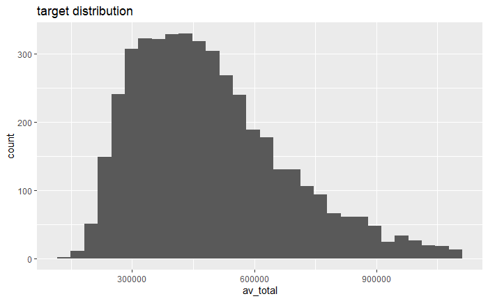

```r
options(scipen = 999)
raw_data %>%
  group_by(av_total) %>%
  summarise(n=n()) %>%
  ungroup() %>%
  ggplot(aes(av_total)) +
  geom_histogram(bins = 30) +
  labs(title="target distribution")
```

# exploration

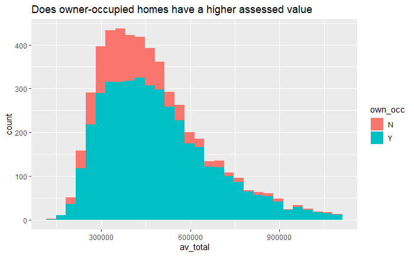

```r
# OWN_OCC
raw_data %>%
  group_by(own_occ, av_total) %>%
  summarise(n=n()) %>%
  ggplot(aes(av_total,fill=own_occ)) +
  geom_histogram(bins=30) +
  labs(title="Does owner-occupied homes have a higher assessed value")
```

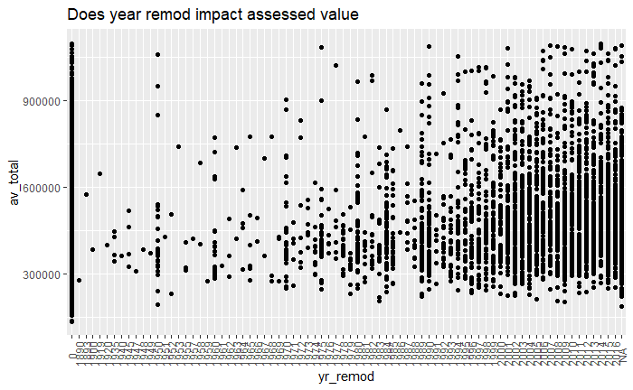

```r
# YEAR_REMOD
raw_data %>%
  ggplot(aes(yr_remod,av_total)) +
  geom_point() +
  labs(title="Does year remod impact assessed value") +
  theme(axis.text.x = element_text(angle = 90, vjust = 0.5, hjust=0.4))
```

# Initial screening and exploration

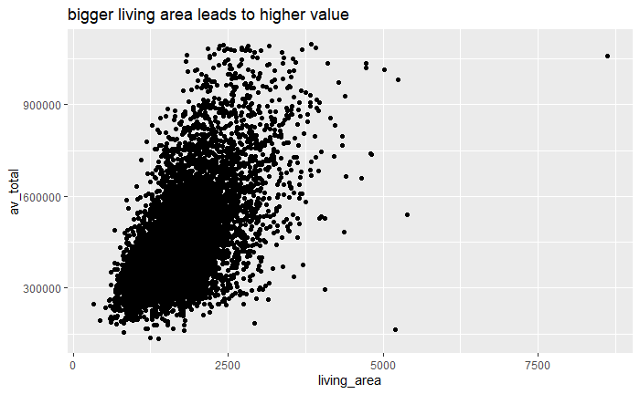

```r
# living area
raw_data %>%
  ggplot(aes(living_area, av_total)) +
  geom_point() +
  labs(title="bigger living area leads to higher value")
```

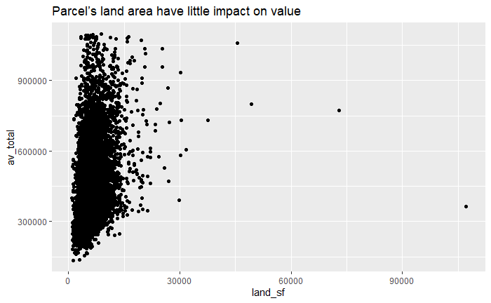

```r
# land_sf
raw_data %>%
  ggplot(aes(land_sf, av_total)) +
  geom_point() +
  labs(title="Parcel’s land area have little impact on value")
```

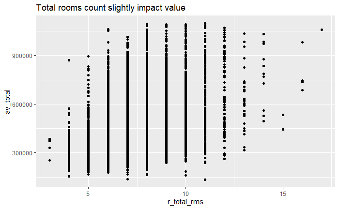

```r
# total_rooms
raw_data %>%
  ggplot(aes(r_total_rms, av_total)) +
  geom_point() +
  labs(title="Total rooms count slightly impact value")
```

```r
# overall condition
raw_data %>%
  group_by(r_ovrall_cnd) %>%
  summarize(avg = mean(av_total),
            median = median(av_total))
```

| r_ovrall_cnd | avg | median |
| --- | --- | --- |
| A | 420985.2 | 401300 |
| E | 1082700.0 | 1082700 |
| F | 338861.8 | 318900 |
| G | 593172.9 | 569100 |
| P | 309931.4 | 285100 |

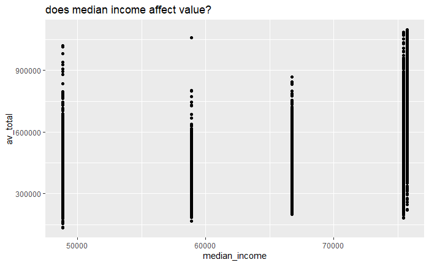

```r
# median income
raw_data %>%
  ggplot(aes(median_income, av_total)) +
  geom_point() +
  labs(title="does median income affect value?")
```

# Split and Defline K-fold

here we want to split our data into 70/30 training to test THEN apply k-fold to our training data you’ll use the kfold grid search to find optimal parameters, which you will then apply a final fit

```r
# -- set a random seed for repeatablity
set.seed(123)

# -- train test split
train_test_spit<- initial_split(raw_data, prop = 0.7)

train <- training(train_test_spit)
test  <- testing(train_test_spit)

# -- k-fold your training data
train_cv_folds <- vfold_cv(train, v=10)


sprintf("Train PCT  : %1.2f%%", nrow(train)/ nrow(raw_data) * 100)
```

```
[1] "Train PCT  : 70.01%"
```

```r
sprintf("Test  PCT  : %1.2f%%", nrow(test)/ nrow(raw_data) * 100)
```

```
[1] "Test  PCT  : 29.99%"
```

```r
sprintf("Kfold Count: %d", nrow(train_cv_folds))
```

```
[1] "Kfold Count: 10"
```

# Define recipe

```r
bos_recipe <-
  recipe(av_total ~ ., data=train) %>%
  # step_rm(pid) %>%
  step_medianimpute(all_numeric(), -all_outcomes()) %>%
  step_novel(all_nominal(), -all_outcomes()) %>%
  step_unknown(all_nominal(), -all_outcomes()) %>%
  step_dummy(all_nominal(), -all_outcomes())
```

# Define models

for both XGB and RF

```r
xgb_model <- boost_tree(
  mtry = tune(),
  trees  = tune(),
  min_n = tune(),
  learn_rate = tune()
  ) %>%
    set_engine("xgboost") %>%
    set_mode("regression")

rf_model <- rand_forest(
  trees = tune(),
  min_n = tune()
  ) %>%
  set_engine("ranger", importance = "permutation") %>%
  set_mode("regression")
```

# Man learning

xD

```r
# xgb_model <- boost_tree(
#   mtry = 20,
#   trees  = 1000,
#   min_n = 7,
#   learn_rate = 0.05
#   ) %>%
#     set_engine("xgboost") %>%
#     set_mode("regression")
#
# xgb_workflow <- workflow() %>%
#   add_recipe(bos_recipe) %>%
#   add_model(xgb_model)
#
# xgb_final_wf <- xgb_workflow
#   # finalize_workflow(xgb_best)
#
# xgb_final_fit <- xgb_final_wf %>%
#   fit(train)
#
# # score
# predict(xgb_final_fit, train) %>%
#   bind_cols(., train) -> train_scored_xgb
#
# predict(xgb_final_fit, test, type="numeric") %>%
#   bind_cols(.,test) -> test_scored_xgb
#
# # Metrics: Train and Test
# train_scored_xgb %>%
#   mutate(part="train") %>%
#   bind_rows(test_scored_xgb %>%
#               mutate(part = "test")) %>%
#   group_by(part) %>%
#   metrics(av_total, estimate = .pred) %>%
#   filter(.metric %in% c('rmse','rsq')) %>%
#   pivot_wider(names_from = .metric, values_from=.estimate) %>%
#   print()
```

# Define workflows

```r
xgb_workflow <- workflow() %>%
  add_recipe(bos_recipe) %>%
  add_model(xgb_model)

rf_workflow <- workflow() %>%
  add_recipe(bos_recipe) %>%
  add_model(rf_model)
```

# set up tuning grids

```r
# --  xgb grid
xgb_tune_grid <- grid_regular(mtry(c(16,20)),
                              trees(c(1000,1000)),
                              min_n(c(6,10)),
                              learn_rate(c(-2,-2)),
                              levels = 5)

print(xgb_tune_grid)
```

| mtry | trees | min_n | learn_rate |
| --- | --- | --- | --- |
| 16 | 1000 | 6 | 0.01 |
| 17 | 1000 | 6 | 0.01 |
| 18 | 1000 | 6 | 0.01 |
| 19 | 1000 | 6 | 0.01 |
| 20 | 1000 | 6 | 0.01 |
| 16 | 1000 | 7 | 0.01 |
| 17 | 1000 | 7 | 0.01 |
| 18 | 1000 | 7 | 0.01 |
| 19 | 1000 | 7 | 0.01 |
| 20 | 1000 | 7 | 0.01 |

[output cut: 115 more lines]

```r
# -- rf grid
rf_tune_grid <- grid_regular(trees(c(1000,1000)),
                             min_n(),
                             levels = 5)

print(rf_tune_grid)
```

| trees | min_n |
| --- | --- |
| 1000 | 2 |
| 1000 | 11 |
| 1000 | 21 |
| 1000 | 30 |
| 1000 | 40 |

# Kick the fit off with parallel computation

```r
all_cores <- detectCores(logical = TRUE)
sprintf("# of Logical Cores: %d", all_cores)
```

```
[1] "# of Logical Cores: 12"
```

```r
cl <- makeCluster(all_cores)

registerDoParallel(cl)

# -- XGB
xgb_tuning_results <- xgb_workflow %>%
  tune_grid(
    resamples = train_cv_folds,
    grid = xgb_tune_grid
  )

# -- rf
rf_tuning_results <- rf_workflow %>%
  tune_grid(
    resamples = train_cv_folds,
    grid = rf_tune_grid
  )
```

# collect and prepare for eval

```r
# -- xgb

xgb_tuning_results %>%
  collect_metrics() %>%
  mutate_if(is.numeric, round, 3)
```

[output not shown]

# Select the best and refit

```r
# -- xgb
xgb_tuning_results %>%
  show_best("rmse") %>%
  print()
```

[output not shown]

```r
xgb_best <- xgb_tuning_results %>%
  select_best("rmse")

xgb_final_wf <- xgb_workflow %>%
  finalize_workflow(xgb_best)

xgb_final_fit <- xgb_final_wf %>%
  fit(train)

# -- rf
rf_tuning_results %>%
  show_best("rmse")
```

| trees | min_n | .metric | .estimator | mean | n | std_err | .config |
| --- | --- | --- | --- | --- | --- | --- | --- |
| 1000 | 2 | rmse | standard | 61222.02 | 10 | 996.7135 | Model1 |
| 1000 | 11 | rmse | standard | 61965.89 | 10 | 1005.7069 | Model2 |
| 1000 | 21 | rmse | standard | 63102.37 | 10 | 1062.5489 | Model3 |
| 1000 | 30 | rmse | standard | 64137.81 | 10 | 1138.7884 | Model4 |
| 1000 | 40 | rmse | standard | 65111.22 | 10 | 1158.0651 | Model5 |

```r
rf_best <- rf_tuning_results %>%
  select_best("rmse")

rf_final_wf <- rf_workflow %>%
  finalize_workflow(rf_best)

rf_final_fit <- rf_final_wf %>%
  fit(train)
```

# evaluate

```
`as.tibble()` is deprecated as of tibble 2.0.0.
Please use `as_tibble()` instead.
The signature and semantics have changed, see `?as_tibble`.
```

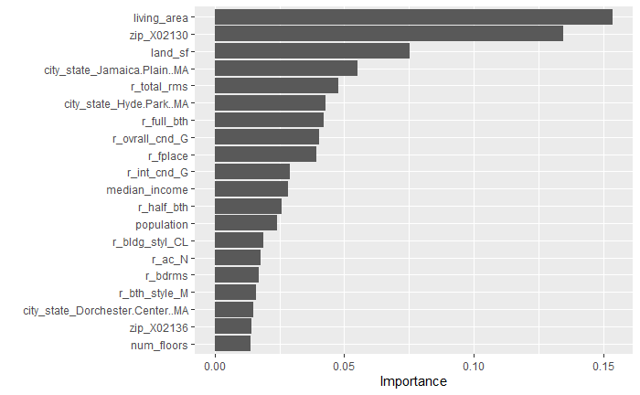

```r
# -- xgb
xgb_final_fit %>%
  pull_workflow_fit() %>%
  vip(n = 20)
```

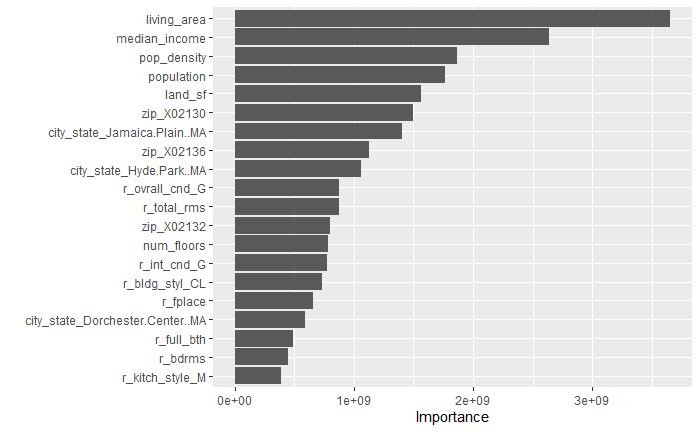

```r
# -- rf
rf_final_fit %>%
  pull_workflow_fit() %>%
  vip(n = 20)
```

```r
regression_eval <- function(model){

# -- score training
  predict(model, train) %>%
    bind_cols(.,train)-> train_scored

  predict(model, test, type="numeric") %>%
    bind_cols(.,test)-> test_scored

  # -- Metrics: Train and Test
  train_scored %>%
    mutate(part="train") %>%
    bind_rows(test_scored %>% mutate(part = "test")) %>%
    group_by(part) %>%
    metrics(av_total, estimate = .pred) %>%
    filter(.metric %in% c('rmse','rsq')) %>%
    pivot_wider(names_from = .metric, values_from=.estimate) %>%
    print()

}

regression_eval(xgb_final_fit)
```

| part | .estimator | rmse | rsq |
| --- | --- | --- | --- |
| test | standard | 52334.86 | 0.8727711 |
| train | standard | 39882.23 | 0.9279598 |

```r
regression_eval(rf_final_fit)
```

| part | .estimator | rmse | rsq |
| --- | --- | --- | --- |
| test | standard | 58880.89 | 0.8587432 |
| train | standard | 38409.58 | 0.9478181 |

1st run: learn_rate -> 0.100 is good, increase trees by 100 could lower mean by ~400 2nd run: tree_depth close to 4 is good 3rd run: xgb -> min_n(30,40) mtry(15,20) rf -> min_n=2 mtry=20 4th: mtry(16,20), learn rate(-2,-0.8) -> best 52334 5rd: mtry(c(16,20)), min_n(c(6,10)), learn_rate(c(-2,-2))

# predict holdout

```r
predict(xgb_final_fit, holdout) %>%
  bind_cols(., holdout %>%
              select(pid)
            ) %>%
  select(pid, av_total=.pred) -> kaggle_submit
```

[output not shown]

```r
write_csv(kaggle_submit, "proj2_submission4.csv")
```

# Let’s see what would happen if I follow every bit of details in the sample code …

a few things here: I dont see the yr_remod is categorical - numeric does not make sense why would tuning 2 parameters yield a far better result than tuning 4 to 5?

```r
# load the data, clean the names, make factors

df <-read_csv("../Project 2/boston_train.csv") %>%
  clean_names() %>%
  mutate_if(is.character,factor)
holdout <-read_csv("../Project 2/boston_holdout.csv") %>%
  clean_names() %>%
  mutate_if(is.character,factor)
# -- set a random seed for repeatablity
set.seed(42)

# -- train test split
train_test_spit<- initial_split(df, prop = 0.7)

train <- training(train_test_spit)
test  <- testing(train_test_spit)

# -- k-fold your training data
train_cv_folds <- vfold_cv(train, v=5)

sprintf("remeber you are using folds to find parameters but still need to evaluate on train and test after you've found your hyper parameters")
```

```
[1] "remeber you are using folds to find parameters but still need to evaluate on train and test after you've found your hyper parameters"
```

```r
sprintf("Train PCT  : %1.2f%%", nrow(train)/ nrow(df) * 100)
```

```
[1] "Train PCT  : 70.01%"
```

```r
sprintf("Test  PCT  : %1.2f%%", nrow(test)/ nrow(df) * 100)
```

```
[1] "Test  PCT  : 29.99%"
```

```r
sprintf("Kfold Count: %d", nrow(train_cv_folds))
```

```
[1] "Kfold Count: 5"
```

```r
# -- define recipe
bos_recipe <-
  recipe(av_total ~ ., data=train) %>%
  step_rm(pid) %>%
  step_medianimpute(all_numeric(), -all_outcomes()) %>%
  step_unknown(all_nominal(), -all_outcomes()) %>%
  step_dummy(all_nominal(), -all_outcomes())

# -- define models
xgb_model <- boost_tree(
    trees  = tune(),
    learn_rate = tune()) %>%
  set_engine("xgboost") %>%
  set_mode("regression")

rf_model <- rand_forest(
  trees = tune(),
  min_n = tune()) %>%
  set_engine("ranger", importance = "permutation") %>%
  set_mode("regression")

# -- define workflows
xgb_workflow <- workflow() %>%
  add_recipe(bos_recipe) %>%
  add_model(xgb_model)

rf_workflow <- workflow() %>%
  add_recipe(bos_recipe)  %>%
  add_model(rf_model)

# --  xgb grid
xgb_tune_grid <- grid_regular(trees(c(100,1000)),
                              learn_rate(),
                              levels = 10)

print(xgb_tune_grid)
```

| trees | learn_rate |
| --- | --- |
| 100 | 0.0000000001 |
| 200 | 0.0000000001 |
| 300 | 0.0000000001 |
| 400 | 0.0000000001 |
| 500 | 0.0000000001 |
| 600 | 0.0000000001 |
| 700 | 0.0000000001 |
| 800 | 0.0000000001 |
| 900 | 0.0000000001 |
| 1000 | 0.0000000001 |

[output cut: 90 more lines]

```r
# -- rf grid
rf_tune_grid <- grid_regular(trees(c(100,1000)),
                          min_n(),
                          levels = 5)

print(rf_tune_grid)
```

| trees | min_n |
| --- | --- |
| 100 | 2 |
| 325 | 2 |
| 550 | 2 |
| 775 | 2 |
| 1000 | 2 |
| 100 | 11 |
| 325 | 11 |
| 550 | 11 |
| 775 | 11 |
| 1000 | 11 |

[output cut: 15 more lines]

```r
all_cores <- detectCores(logical = TRUE)
sprintf("# of Logical Cores: %d", all_cores)
```

```
[1] "# of Logical Cores: 12"
```

```r
cl <- makeCluster(all_cores)

registerDoParallel(cl)

# -- K-Fold XGB
xgb_tuning_results <-
  xgb_workflow %>%
  tune_grid(
    resamples = train_cv_folds,
    grid = xgb_tune_grid,
    #control = control_resamples(save_pred = TRUE)
    )
# -- k-fold RF
rf_tuning_results <-
  rf_workflow %>%
  tune_grid(
    resamples = train_cv_folds,
    grid = rf_tune_grid,
    #control = control_resamples(save_pred = TRUE)
    )


# -- evaluate your Hyper Parameter K-Folds
xgb_tuning_results %>%
  collect_metrics() %>%
  mutate_if(is.numeric, round,3) %>%
  pivot_wider(names_from = .metric, values_from=c(mean, std_err))
```

| trees | learn_rate | .estimator | n | .config | mean_rmse | mean_rsq | std_err_rmse | std_err_rsq |
| --- | --- | --- | --- | --- | --- | --- | --- | --- |
| 100 | 0.000 | standard | 5 | Model001 | 472064.36 | 0.738 | 2954.350 | 0.007 |
| 200 | 0.000 | standard | 5 | Model002 | 472064.35 | 0.738 | 2954.350 | 0.007 |
| 300 | 0.000 | standard | 5 | Model003 | 472064.35 | 0.738 | 2954.350 | 0.007 |
| 400 | 0.000 | standard | 5 | Model004 | 472064.35 | 0.738 | 2954.350 | 0.007 |
| 500 | 0.000 | standard | 5 | Model005 | 472064.34 | 0.738 | 2954.350 | 0.007 |
| 600 | 0.000 | standard | 5 | Model006 | 472064.34 | 0.738 | 2954.350 | 0.007 |
| 700 | 0.000 | standard | 5 | Model007 | 472064.33 | 0.738 | 2954.350 | 0.007 |
| 800 | 0.000 | standard | 5 | Model008 | 472064.33 | 0.738 | 2954.350 | 0.007 |
| 900 | 0.000 | standard | 5 | Model009 | 472064.32 | 0.738 | 2954.350 | 0.007 |
| 1000 | 0.000 | standard | 5 | Model010 | 472064.32 | 0.738 | 2954.350 | 0.007 |

[output cut: 90 more lines]

```r
xgb_tuning_results %>%
  show_best("rmse") %>%
  print()
```

| trees | learn_rate | .metric | .estimator | mean | n | std_err | .config |
| --- | --- | --- | --- | --- | --- | --- | --- |
| 300 | 0.1 | rmse | standard | 52309.08 | 5 | 746.6375 | Model093 |
| 400 | 0.1 | rmse | standard | 52353.61 | 5 | 736.5208 | Model094 |
| 500 | 0.1 | rmse | standard | 52418.25 | 5 | 778.4902 | Model095 |
| 200 | 0.1 | rmse | standard | 52418.56 | 5 | 739.5353 | Model092 |
| 600 | 0.1 | rmse | standard | 52476.72 | 5 | 764.0194 | Model096 |

```r
xgb_best_rmse <- xgb_tuning_results %>%
  select_best("rmse")

rf_tuning_results %>%
  collect_metrics() %>%
  mutate_if(is.numeric, round,3) %>%
  pivot_wider(names_from = .metric, values_from=c(mean, std_err))
```

| trees | min_n | .estimator | n | .config | mean_rmse | mean_rsq | std_err_rmse | std_err_rsq |
| --- | --- | --- | --- | --- | --- | --- | --- | --- |
| 100 | 2 | standard | 5 | Model01 | 57759.84 | 0.856 | 1172.430 | 0.003 |
| 325 | 2 | standard | 5 | Model02 | 57648.07 | 0.857 | 1030.715 | 0.002 |
| 550 | 2 | standard | 5 | Model03 | 57573.81 | 0.858 | 1116.478 | 0.003 |
| 775 | 2 | standard | 5 | Model04 | 57563.35 | 0.858 | 1109.020 | 0.003 |
| 1000 | 2 | standard | 5 | Model05 | 57552.80 | 0.858 | 1114.225 | 0.003 |
| 100 | 11 | standard | 5 | Model06 | 58629.93 | 0.853 | 1251.200 | 0.003 |
| 325 | 11 | standard | 5 | Model07 | 58456.01 | 0.854 | 1052.858 | 0.002 |
| 550 | 11 | standard | 5 | Model08 | 58363.14 | 0.855 | 1034.868 | 0.002 |
| 775 | 11 | standard | 5 | Model09 | 58336.18 | 0.855 | 1145.627 | 0.003 |
| 1000 | 11 | standard | 5 | Model10 | 58331.33 | 0.855 | 1116.381 | 0.002 |

[output cut: 15 more lines]

```r
rf_tuning_results %>%
  show_best("rmse") %>%
  print()
```

| trees | min_n | .metric | .estimator | mean | n | std_err | .config |
| --- | --- | --- | --- | --- | --- | --- | --- |
| 1000 | 2 | rmse | standard | 57552.80 | 5 | 1114.225 | Model05 |
| 775 | 2 | rmse | standard | 57563.35 | 5 | 1109.020 | Model04 |
| 550 | 2 | rmse | standard | 57573.81 | 5 | 1116.478 | Model03 |
| 325 | 2 | rmse | standard | 57648.07 | 5 | 1030.715 | Model02 |
| 100 | 2 | rmse | standard | 57759.84 | 5 | 1172.430 | Model01 |

```r
rf_best_rmse <- rf_tuning_results %>%
  select_best("rmse")

print(xgb_best_rmse)
```

| trees | learn_rate | .config |
| --- | --- | --- |
| 300 | 0.1 | Model093 |

```r
print(rf_best_rmse)
```

| trees | min_n | .config |
| --- | --- | --- |
| 1000 | 2 | Model05 |

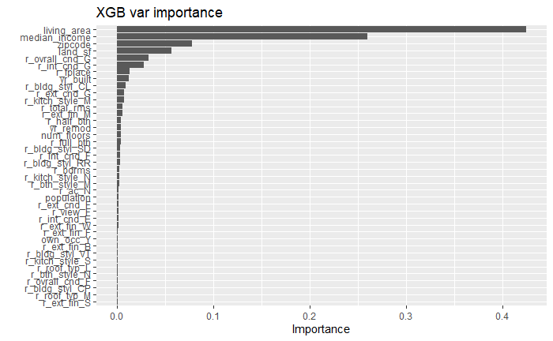

```r
# -- finalize XBG workflow
xgb_final_wf <-
  xgb_workflow %>%
  finalize_workflow(xgb_best_rmse)

xgb_final_fit  <-
  xgb_final_wf %>%
  fit(data = train)
# -- finalize RF workflow
rf_final_wf <-
  rf_workflow %>%
  finalize_workflow(rf_best_rmse)

rf_final_fit  <-
  rf_final_wf %>%
  fit(data = train)

xgb_final_fit %>%
  pull_workflow_fit() %>%
  vip(40) + labs(title = "XGB var importance")
```

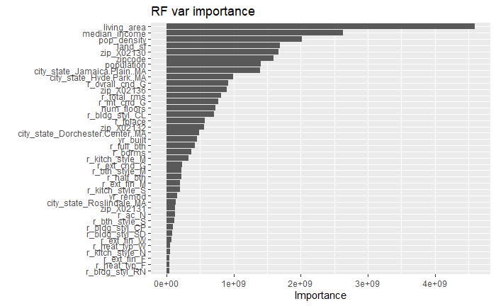

```r
rf_final_fit %>%
  pull_workflow_fit() %>%
  vip(40)+ labs(title = "RF var importance")
```

```r
regression_eval <- function(model){

# -- score training
  predict(model, train) %>%
    bind_cols(.,train)-> train_scored

  predict(model, test, type="numeric") %>%
    bind_cols(.,test)-> test_scored

  # -- Metrics: Train and Test
  train_scored %>%
    mutate(part="train") %>%
      bind_rows(test_scored %>% mutate(part = "test")) %>%
    group_by(part) %>%
    metrics(av_total, estimate = .pred) %>%
    filter(.metric %in% c('rmse','rsq')) %>%
    pivot_wider(names_from = .metric, values_from=.estimate) %>%
    print()

}

regression_eval(xgb_final_fit)
```

| part | .estimator | rmse | rsq |
| --- | --- | --- | --- |
| test | standard | 50239.32 | 0.8864745 |
| train | standard | 27950.33 | 0.9642612 |

```r
regression_eval(rf_final_fit)
```

| part | .estimator | rmse | rsq |
| --- | --- | --- | --- |
| test | standard | 56551.11 | 0.8657286 |
| train | standard | 30487.49 | 0.9644810 |

```r
predict(xgb_final_fit, holdout) %>%
  bind_cols(.,holdout %>% select(pid)) %>%
  select(pid, av_total = .pred) -> sample_submission
```

[output not shown]

```r
write_csv(sample_submission, "sample_submission2.csv")
```

sample submission gives us 51728 on Kaggle - super confusing…

xgb_tune_grid <- grid_regular(trees(c(100,1000)), learn_rate(), levels = 5) -> 50272

xgb_tune_grid <- grid_regular(trees(c(100,1000)), min_n(), learn_rate(), levels = 5) -> 49799 BAD KAGGLE

xgb_tune_grid <- grid_regular(trees(c(100,1000)), tree_depth(), learn_rate(), levels = 10) -> 49727 BAD KAGGLE

# predictions file

for regression problems we want to compare histograms of predicted vs actual av_total they should have same / similar shape.

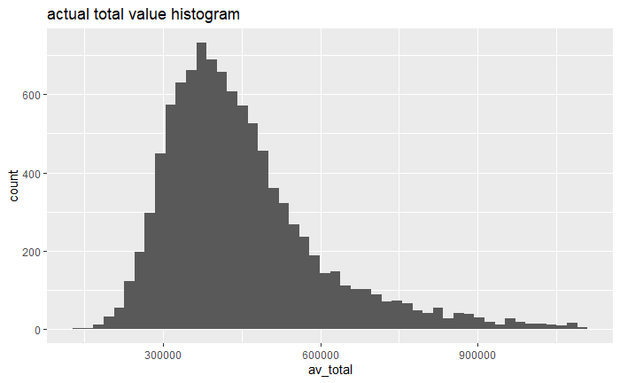

```r
options(scipen = 999)
df %>%
  ggplot(aes(av_total)) +
  geom_histogram(bins = 50) +
  labs(title="actual total value histogram")
```

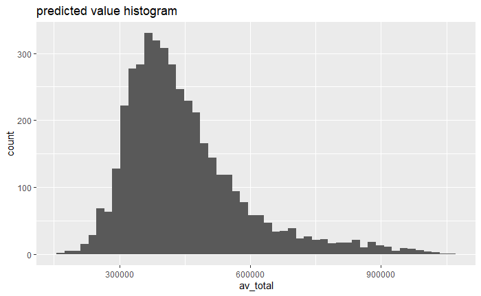

```r
sample_submission %>%
  ggplot(aes(av_total)) +
  geom_histogram(bins = 50) +
  labs(title="predicted value histogram")
```